# Collate the PASA annotation updates

Nicolas Delhomme

2015-08-27

# 1 Setup

Set the working dir

```r
setwd("/mnt/picea/projects/aspseq/asp201/rna/PASA/annotation")
```

Load libraries

```r
suppressPackageStartupMessages(library(DESeq2))
suppressPackageStartupMessages(library(genomeIntervals))
suppressPackageStartupMessages(library(GenomicRanges))
suppressPackageStartupMessages(library(ggplot2))
suppressPackageStartupMessages(library(gplots))
suppressPackageStartupMessages(library(igraph))
suppressPackageStartupMessages(library(pander))
suppressPackageStartupMessages(library(RColorBrewer))
suppressPackageStartupMessages(library(scales))
suppressPackageStartupMessages(library(vcd))
suppressPackageStartupMessages(library(vsn))
```

Create a palette

```r
cols <- brewer.pal(10,"Paired")[c(1:4,9:10)]
```

Record plotting params

```r
mar <- par("mar")
```

Create a function to get the mRNA per gene and exons per mRNA

```r
"collectRelationships" <- function(gff, dataset.name="X"){
  IDs <- getGffAttribute(gff,"ID")
  p.list <- strsplit(getGffAttribute(gff,"Parent"),",")
  typs <- rep(gff$type,elementLengths(p.list))
  Parents <- unlist(p.list)

  mRNA=as.integer(table(Parents[typs %in% c("mRNA","tRNA")][Parents[typs %in% c("mRNA","tRNA")] %in% IDs[gff$type=="gene"]]))
  exon=as.integer(table(Parents[typs=="exon"][Parents[typs=="exon"] %in% IDs[gff$type %in% c("mRNA","tRNA")]]))
  stopifnot(sum(mRNA)==length(exon))

  return(data.frame(Dataset=dataset.name,
                    Feature=rep(c("mRNA","exon"),
                                c(length(mRNA),
                                  length(exon))),
                    Number=c(mRNA,exon)))
}

"collectSizes" <- function(gff,dataset.name="X"){

  ## get the introns
  ex.sel <- gff$type=="exon"
  p.list <- strsplit(getGffAttribute(gff[ex.sel,],"Parent"),",")
  Parents <- unlist(p.list)
  grng <- sort(GRanges(seqnames = Parents,
                       ranges = IRanges(
                         rep(gff[ex.sel,1],elementLengths(p.list)),
                         rep(gff[ex.sel,2],elementLengths(p.list))),
                       scf = rep(seq_name(gff[ex.sel,]),elementLengths(p.list))
  ))
  starts <- start(grng)[match(unique(Parents),Parents)]
  names(starts) <- unique(Parents)
  intron.grng <- gaps(grng,start=starts)
  ## de-duplicate (remove exact coordinates dups)
  ## we do not use the strand as gaps is an unstranded method
  intron.dup <- duplicated(paste(
    grng$scf[match(as.character(seqnames(intron.grng)),
                   as.character(seqnames(grng)))],
    start(intron.grng),
    end(intron.grng),sep="_"))
  intron <- width(intron.grng)[!intron.dup]

  ## For the rest of the features, ignore duplicates!
  dups <- duplicated(paste(seq_name(gff),
                           gff[,1],
                           gff[,2],
                           gff$type,
                           gff$strand,sep="_"))
  gff <- gff[!dups,]

  # get all sizes
  sizes <- gff[,2] - gff[,1] + 1

  # return a data.frame (melted for ggplots2)
  return(data.frame(Dataset=dataset.name,
                    Length=c(sizes,intron),
                    Feature=c(as.character(gff$type),rep("intron",length(intron))))
  )
}
```

# 2 Annotations

We first list them all * Ab Initio P. tremula

```r
Potra01 <- "/mnt/picea/storage/reference/Populus-tremula/v1.0/gff3/Potra01-genome-with-Potri-attribute.gff3.gz"
```

- Ab Initio P. tremuloides

```r
Potrs01 <- "/mnt/picea/storage/reference/Populus-tremuloides/v1.0/gff3/Potrs01-genome.gff3.gz"
```

- P. trichocarpa

```r
Potri03 <- "/mnt/picea/storage/reference/Populus-trichocarpa/v3.0/gff/Ptrichocarpa_v3.0_210_gene_exons.gff3"
```

- Potra01 Post PASA update

```r
Potra01.PASA <- "Potra01-genome-post-PASA.gff3"
```

- Potra01 post PASA update supplemented with Potri03

```r
Potra01.PASA.Potri03 <- "Potra01-genome-post-PASA-with-Potri03.gff3"
```

Create a list of names

```r
nams <- list("Potra01",
             "Potrs01",
             "Potri03",
             "Potra01+PASA",
             "Potra01+PASA+Potri03")
```

## 2.1 Read in the gff

```r
gffs <- mclapply(
  list(Potra01,
       Potrs01,
       Potri03,
       Potra01.PASA,
       Potra01.PASA.Potri03),
  readGff3,mc.cores=5L)

names(gffs) <- nams
```

## 2.2 Shortly summarize them

```r
tab <- lapply(lapply(gffs,"[[","type"),table)
```

We merge the tRNA as mRNA in the ab.initio - just to have more comparable results.

These will be re-annotated in the PASA annotation later

```r
sprintf("We ignore %s and %s tRNAs from Populus tremula and tremuloides, respectively",
        tab[[1]]["tRNA"],tab[[2]]["tRNA"])
```

```
## [1] "We ignore 608 and 633 tRNAs from Populus tremula and tremuloides, respectively"
```

```r
tab[[1]]["mRNA"] <- sum(tab[[1]][names(tab[[1]]) %in% c("tRNA","mRNA")])
tab[[1]] <- tab[[1]][names(tab[[1]])!="tRNA"]
tab[[2]]["mRNA"] <- sum(tab[[2]][names(tab[[2]]) %in% c("tRNA","mRNA")])
tab[[2]] <- tab[[2]][names(tab[[2]])!="tRNA"]

tab <- do.call(rbind,tab)
rownames(tab) <- nams
pander(tab)
```

Table continues below

|  | CDS | exon | five_prime_UTR | gene |
| --- | --- | --- | --- | --- |
| **Potra01** | 216139 | 179893 | 36890 | 28246 |
| **Potrs01** | 204254 | 171383 | 34747 | 27508 |
| **Potri03** | 429456 | 460072 | 72833 | 41335 |
| **Potra01+PASA** | 524497 | 585137 | 109052 | 29546 |
| **Potra01+PASA+Potri03** | 526103 | 586504 | 109280 | 30088 |

|  | mRNA | three_prime_UTR |
| --- | --- | --- |
| **Potra01** | 37104 | 38316 |
| **Potrs01** | 35801 | 36051 |
| **Potri03** | 73013 | 73697 |
| **Potra01+PASA** | 84437 | 110273 |
| **Potra01+PASA+Potri03** | 85005 | 110448 |

Then we look up how many Potra01 genes have Potri03 associated IDs

```r
Potra01.Potri03 <- getGffAttribute(gffs[[1]][gffs[[1]]$type=="gene",],"Potri")
sprintf("Out of %s ab initio predicted genes, %s have a Potri03 associated gene",
        length(Potra01.Potri03),sum(!is.na(Potra01.Potri03)))
```

```
## [1] "Out of 28246 ab initio predicted genes, 25546 have a Potri03 associated gene"
```

## 2.3 Data preparation for ggplots2

### 2.3.1 Plot aesthetics

Create the aesthetic so as to easily recycle them

```r
m.aesthetic <- aes(x=Feature,color=Dataset,
                   fill=Dataset,alpha=Dataset)

m.theme <- theme(axis.text.x=element_text(size=12,
                                          face="bold",
                                          angle = 90,
                                          vjust = 0.5,
                                          hjust=1),
                 axis.text.y=element_text(size=12),
                 axis.title=element_blank(),
                 legend.text=element_text(size=12),
                 legend.title=element_text(size=12))

m.fill <- scale_fill_manual(values=c(rep("white",3),cols[c(2,6)]))

m.color <- scale_color_manual(values = cols[c(2,4,6,2,2)])

m.alpha <- scale_alpha_manual(values=c(1,1,1,.5,.5))
```

### 2.3.2 Feature sizes

```r
df.sizes <- do.call(rbind,mcmapply(collectSizes,
                                   gffs,
                                   nams,
                                   SIMPLIFY=FALSE,
                                   mc.cores=5L))
```

### 2.3.3 Feature numbers

```r
df.numbers <- do.call(rbind,mcmapply(collectRelationships,
                                     gffs,
                                     nams,
                                     SIMPLIFY=FALSE,
                                     mc.cores=5L))
```

## 2.4 Comparison

### 2.4.1 Number of features

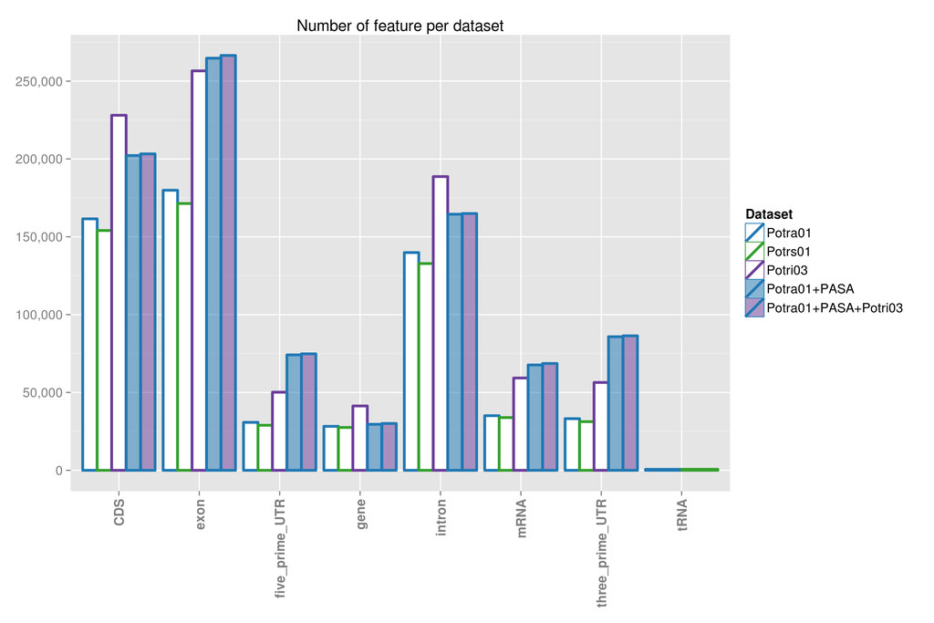

```r
ggplot(df.sizes, m.aesthetic) +
 m.fill + m.color + m.alpha + m.theme +
 geom_bar(stat="bin",position="dodge",lwd=1.2) +
 scale_y_continuous(breaks=seq(0,6e5,length.out = 13),labels=comma) +
 ggtitle("Number of feature per dataset")
```

### Number of feature per parent feature Number of exons per mRNA

Number of mRNAs per genes

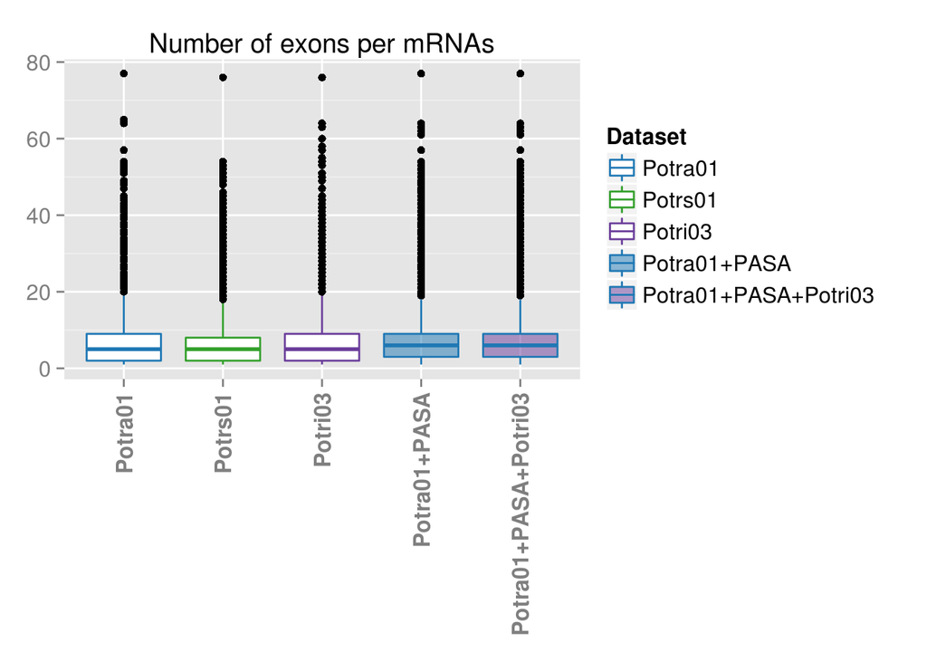

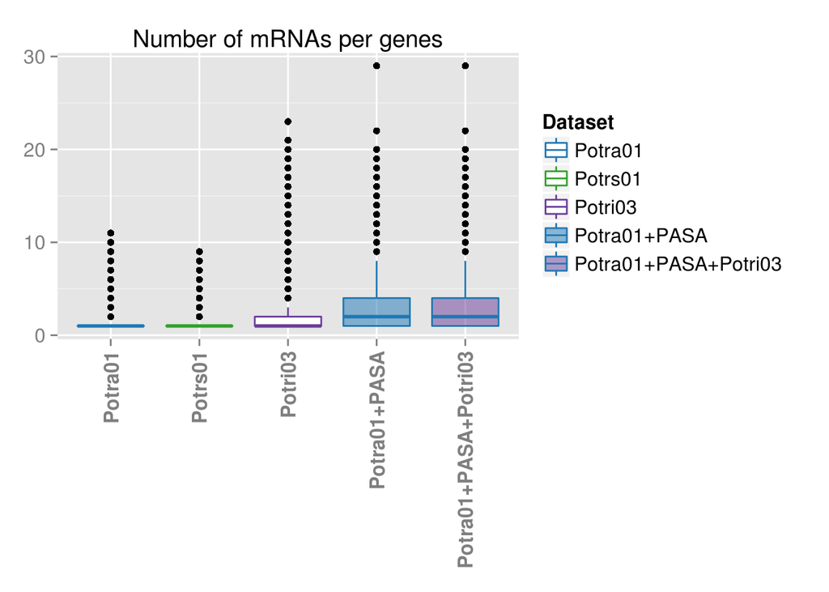

```r
m.aesthetic$x=as.symbol("Dataset")
m.aesthetic$y=as.symbol("Number")

dev.null <- sapply(levels(df.numbers$Feature),function(typ){
  print(ggplot(df.numbers[df.numbers$Feature==typ,],m.aesthetic) +
          geom_boxplot() +
          m.fill + m.color + m.alpha + m.theme +
          ggtitle(paste("Number of ",typ,"s per ",
                        ifelse(typ=="exon","mRNAs","genes"),
                        sep="")))
})
```

### 2.4.2 Feature length

```r
m.aesthetic$y <- as.symbol("Length")
```

For every feature, first on a linear scale, then on a logarithmic scale

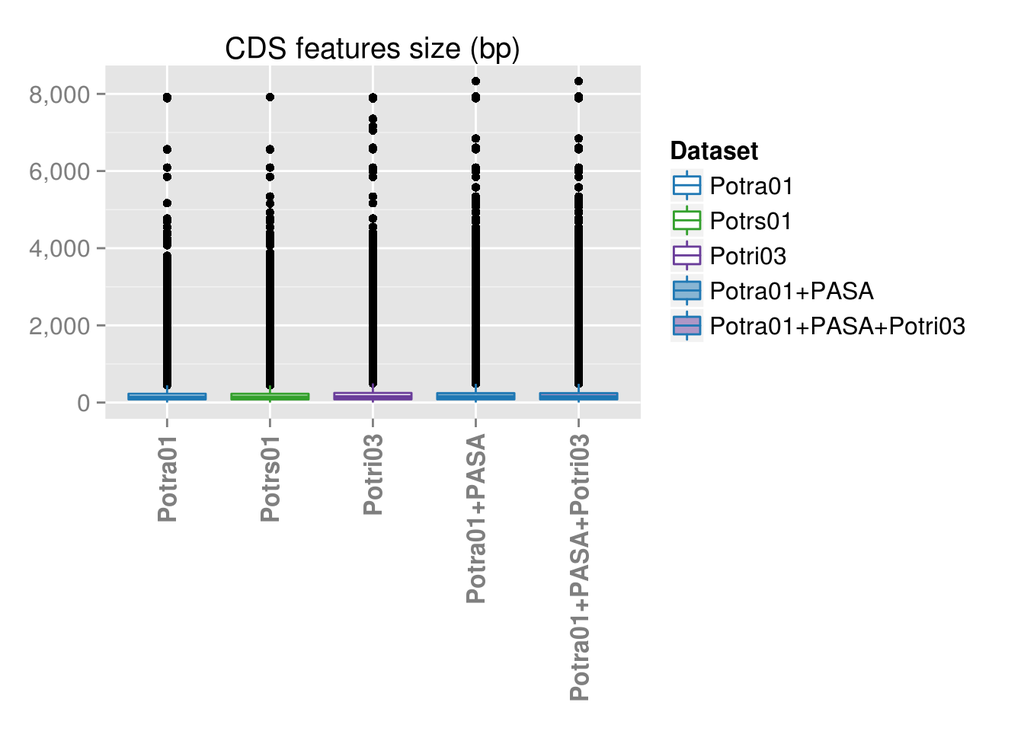

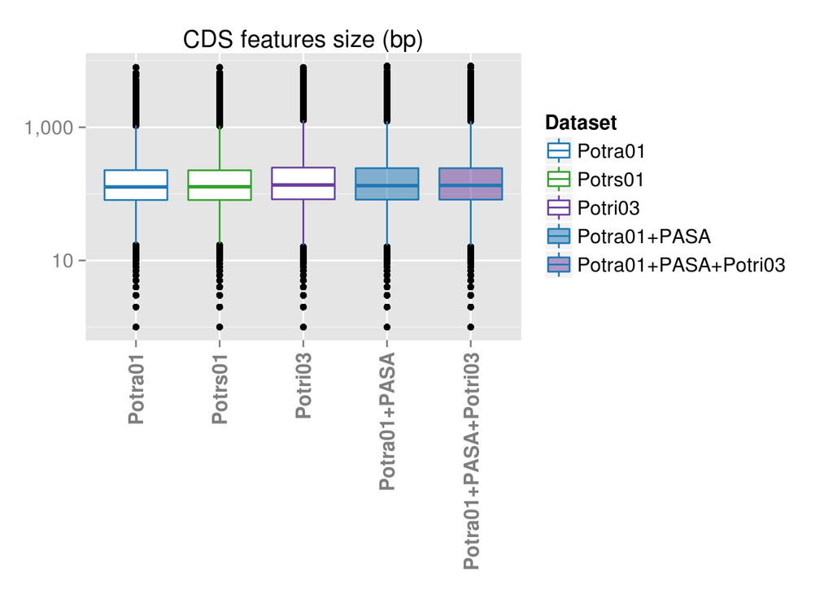

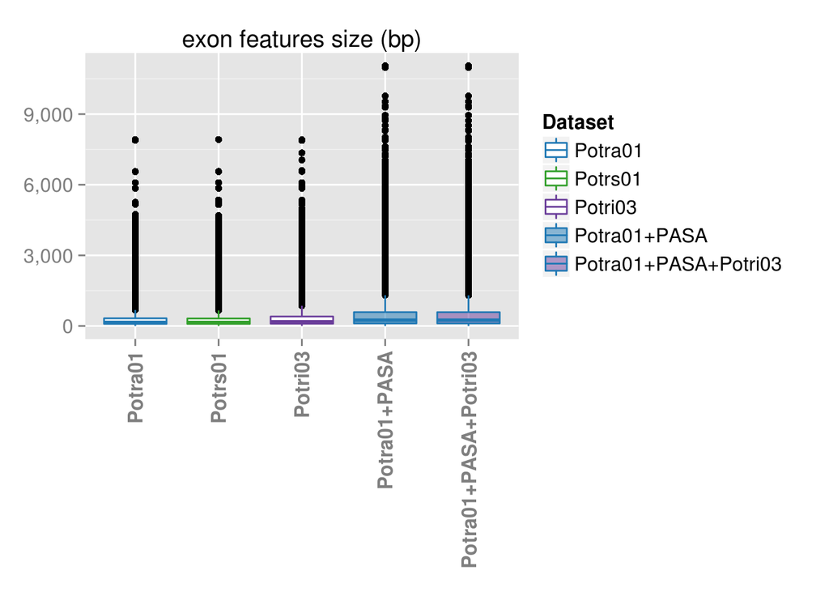

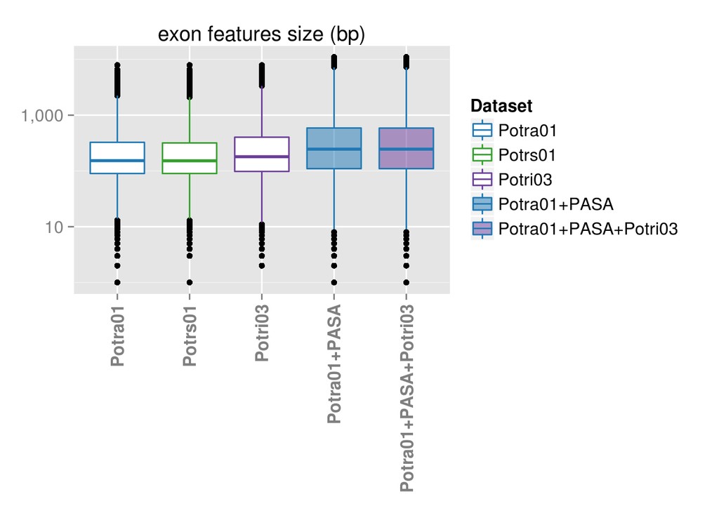

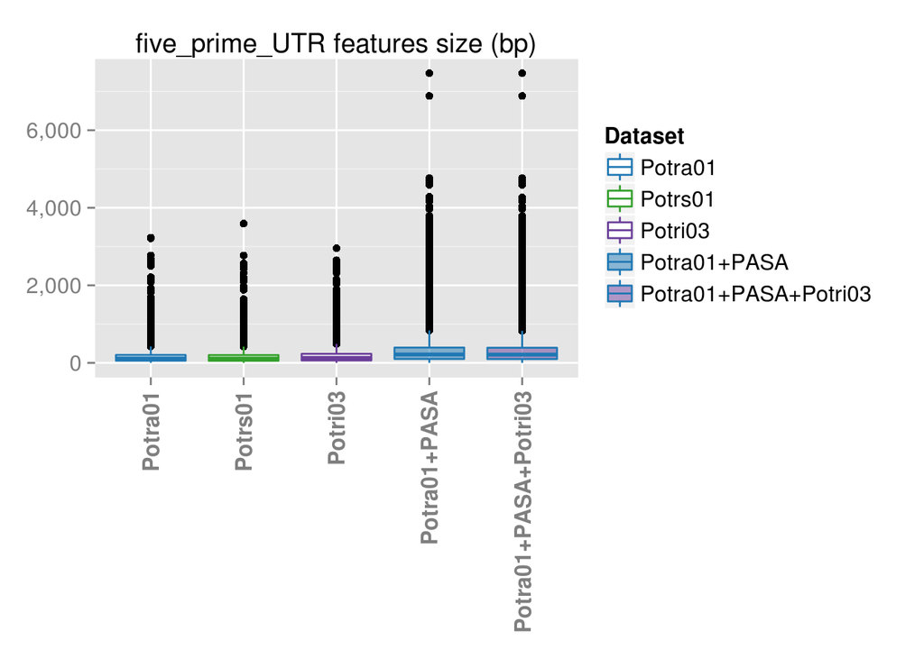

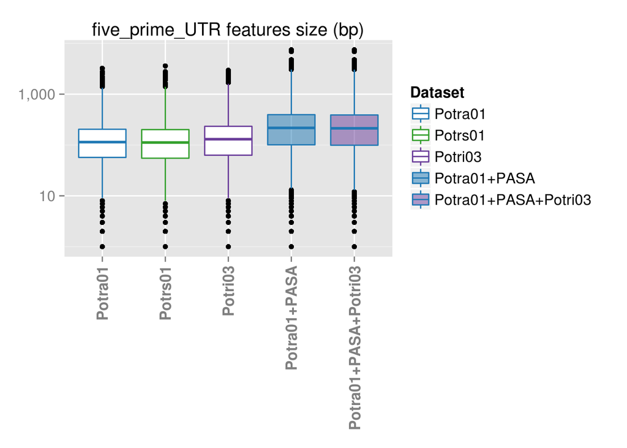

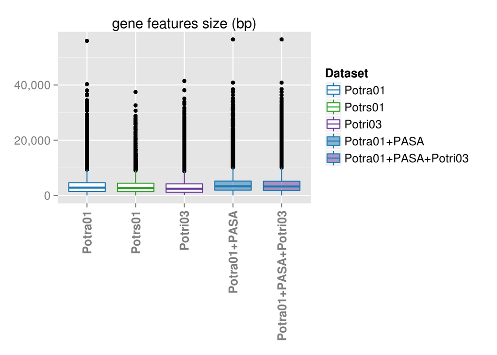

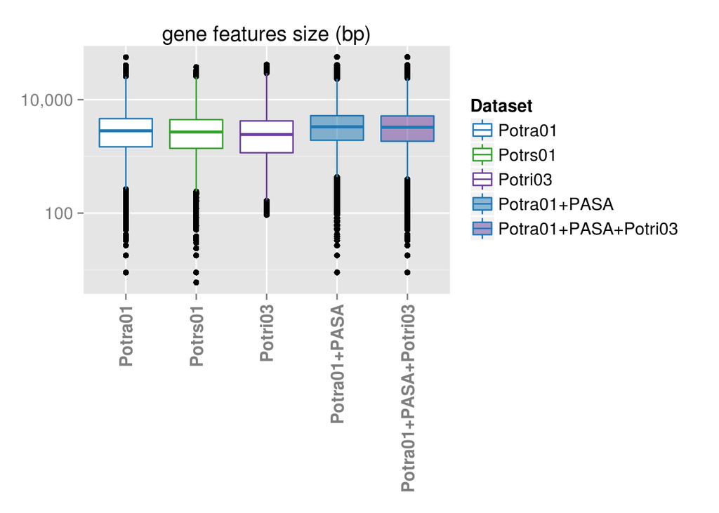

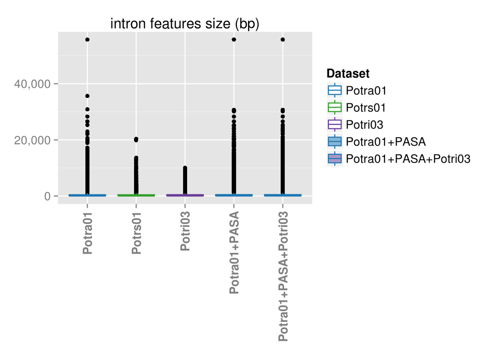

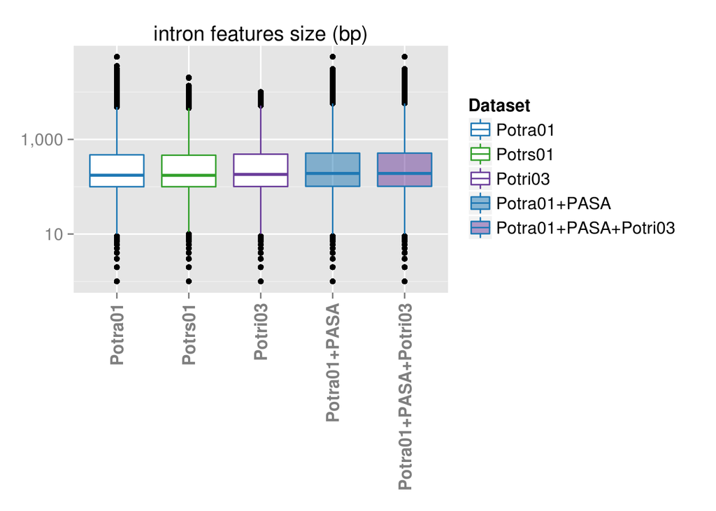

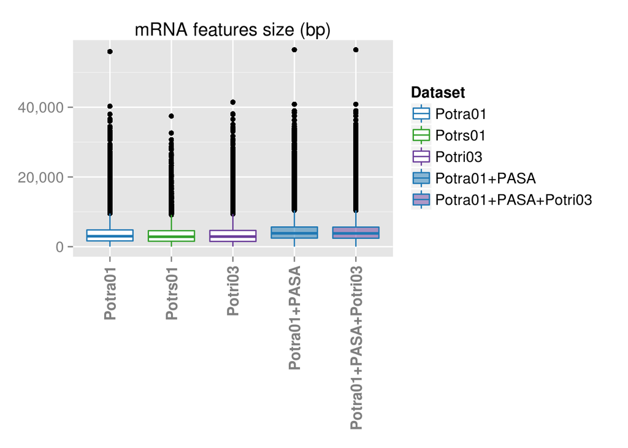

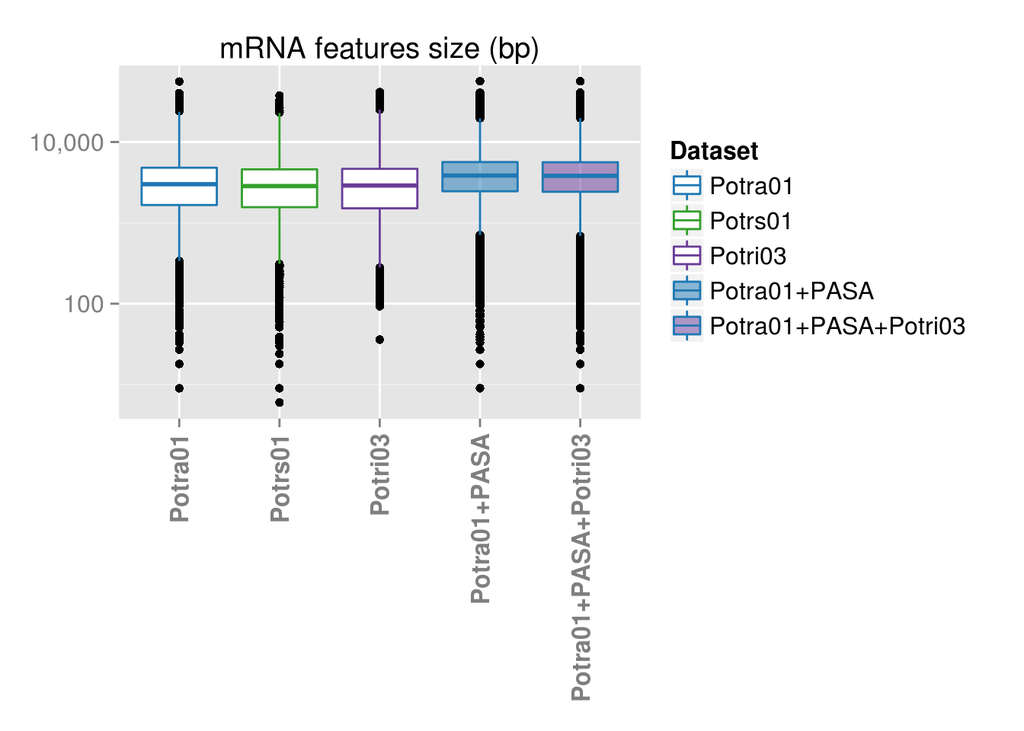

[4 more figures not shown]

```r
dev.null <- sapply(levels(df.sizes$Feature),function(typ){
  # print is neceddary to print the plot and not get
  # the object back
  print(ggplot(df.sizes[df.sizes$Feature==typ,], m.aesthetic) +
          m.fill + m.color + m.alpha + m.theme +
          geom_boxplot() + ggtitle(paste(typ,"features size (bp)")) +
          scale_y_continuous(labels=comma))

  print(ggplot(df.sizes[df.sizes$Feature==typ,], m.aesthetic) +
          m.fill + m.color + m.alpha + m.theme +
          geom_boxplot() + ggtitle(paste(typ,"features size (bp)")) +
          scale_y_log10(labels=comma))
})
```

# 3 Expression

## 3.1 Ab Initio

Read the data

```r
expr <- lapply(list(catalog="../../HTSeq/Potra01/Trinity_all_reads_normalized_K25_C50_pctSD200_STAR.txt",
                    sex="../../../../sex/HTSeq/Potra01/Trinity_all_reads_normalized_K25_C50_pctSD200_STAR.txt",
                    xylem="../../../../xylem-leaf/HTSeq/Potra01/Trinity_all_reads_normalized_K25_C50_pctSD200_STAR.txt",
                    leaf="../../../../leaf_development/HTSeq/Potra01/Trinity_all_reads_normalized_K25_C50_pctSD200_STAR.txt"),
               read.delim,header=FALSE,stringsAsFactors=FALSE)
```

Get the count table

```r
addInfo <- c("__no_feature","__ambiguous","__too_low_aQual","__not_aligned","__alignment_not_unique")
sel <- match(addInfo,expr[[1]][,1])
count.table <- do.call(cbind,lapply(expr,"[",2))[-sel,]
colnames(count.table) <- names(expr)
rownames(count.table) <- expr[[1]][,1][-sel]
```

Extract the HTSeq stat lines

```r
count.stats <- do.call(cbind,lapply(expr,"[",2))[sel,]
colnames(count.stats) <- names(expr)
rownames(count.stats) <- sub("__","",addInfo)
count.stats <- rbind(count.stats,aligned=colSums(count.table))
count.stats <- count.stats[rowSums(count.stats) > 0,]
```

Convert them into percentages

```r
pander(apply(count.stats,2,function(co){round(co*100/sum(co))}))
```

|  | catalog | sex | xylem | leaf |
| --- | --- | --- | --- | --- |
| **no_feature** | 20 | 17 | 9 | 19 |
| **ambiguous** | 4 | 4 | 5 | 4 |
| **alignment_not_unique** | 3 | 4 | 3 | 3 |
| **aligned** | 74 | 75 | 83 | 73 |

Plot the stats

There are no outliers

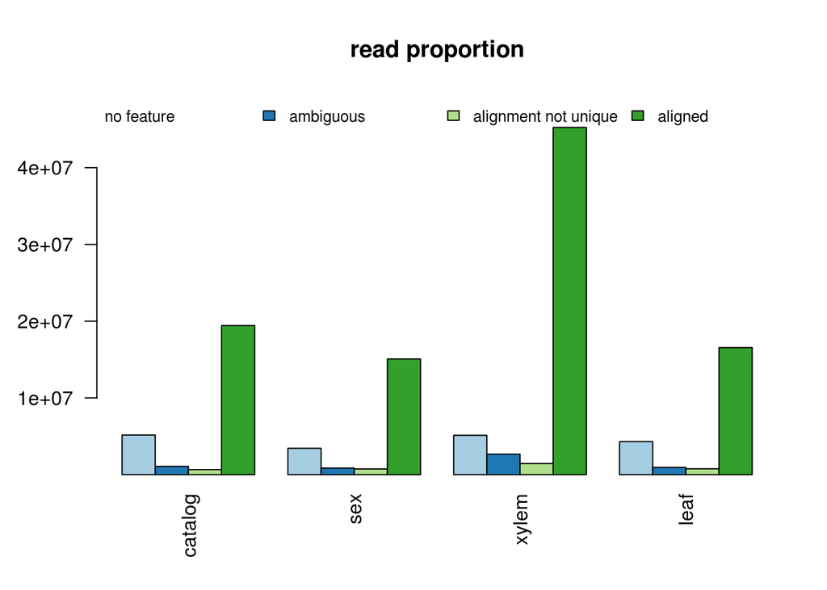

```r
barplot(as.matrix(count.stats),col=cols[1:4],beside=TRUE,las=2,main="read proportion",
        ylim=range(count.stats) + c(0,4e+6))
legend("top",fill=cols[1:4],legend=gsub("_"," ",rownames(count.stats)),
       bty="n",cex=0.8,horiz=TRUE)
```

Average percentage of aligned reads

```r
sprintf("There are %s percent reads aligned on average",
        round(mean(unlist(count.stats["aligned",]/colSums(count.stats)))*100,
              digits=2))
```

```
## [1] "There are 76.25 percent reads aligned on average"
```

Check how many genes are never expressed

```r
sel <- rowSums(count.table) == 0
sprintf("%s%% percent (%s) of %s genes are not expressed",
        round(sum(sel) * 100/ nrow(count.table),digits=1),
        sum(sel),
        nrow(count.table))
```

```
## [1] "8.6% percent (3137) of 36322 genes are not expressed"
```

Create the dds object

```r
conditions <- colnames(count.table)
dds <- DESeqDataSetFromMatrix(
  countData = count.table,
  colData = data.frame(condition=conditions),
  design = ~ condition)
```

Check the size factors (i.e. the sequencing library size effect) There is no big variation, a Variance Stabilizing Transformation can be used (over a Relative Log Transformation)

```r
dds <- estimateSizeFactors(dds)
sizes <- sizeFactors(dds)
names(sizes) <- colnames(count.table)
sizes
```

```
##   catalog       sex     xylem      leaf
## 0.9029515 0.7360770 2.1168048 0.7621539
```

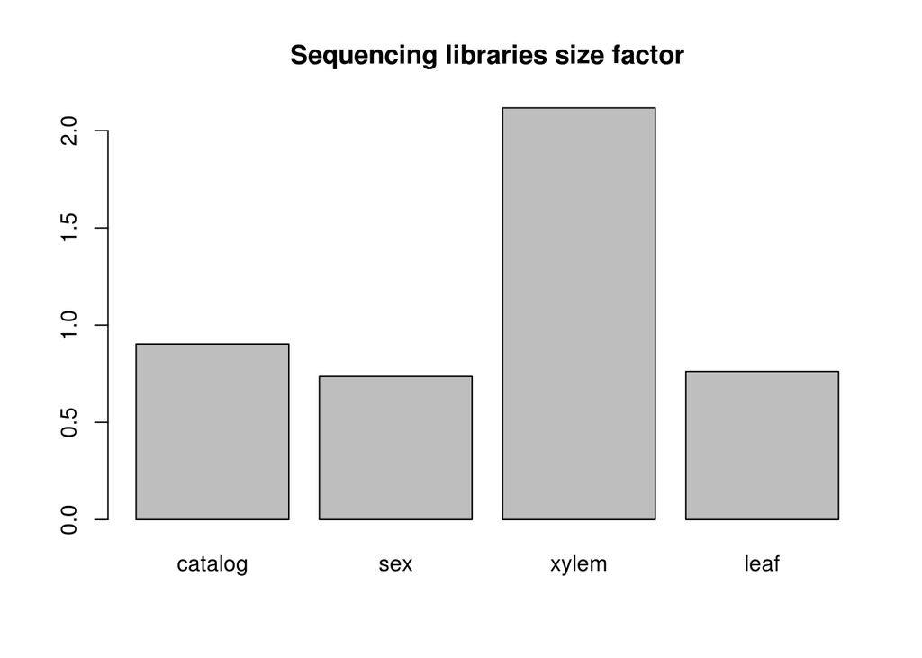

```r
barplot(sizes, main="Sequencing libraries size factor")
```

Perform the VST

```r
colData(dds)$condition <- factor(colData(dds)$condition,
                                 levels=unique(conditions))
vsd <- varianceStabilizingTransformation(dds, blind=TRUE, fitType="local")
vst <- assay(vsd)
colnames(vst) <- colnames(count.table)
vst <- vst - min(vst)
```

Validate the VST

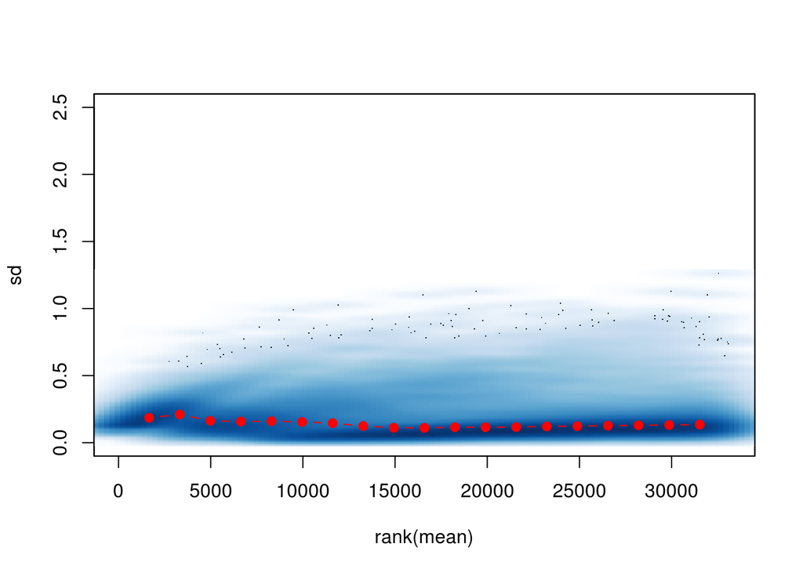

```r
meanSdPlot(vst[rowSums(count.table)>0,], ylim = c(0,2.5))
```

How many Potri03 and Potra01 genes are expressed

```r
sel <- is.na(Potra01.Potri03[match(rownames(vst),
                                   paste(getGffAttribute(gffs[[1]][gffs[[1]]$type=="gene",],"ID"),
                                         "0",sep="."))])
sprintf("Out of the genes found in P. tremula only, %s are not expressed",
        sum(rowSums(vst[sel,])==0))
```

```
## [1] "Out of the genes found in P. tremula only, 3136 are not expressed"
```

```r
sprintf("Out of the genes common to P. tremula and P.trichocarpa, 1 is not expressed",
        sum(rowSums(vst[!sel,])==0))
```

```
## [1] "Out of the genes common to P. tremula and P.trichocarpa, 1 is not expressed"
```

Have a look at the expression average of the Potri03 vs. the Potra01 genes

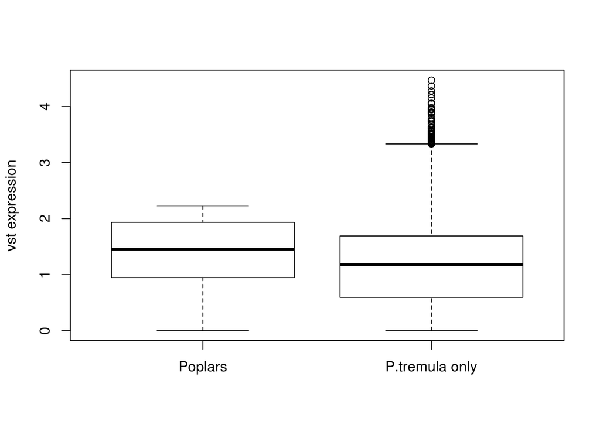

```r
boxplot(split(rowMeans(vst),sel),names=c("Poplars","P.tremula only"),ylab="vst expression")
```

Get a heatmap of the Potra01 genes

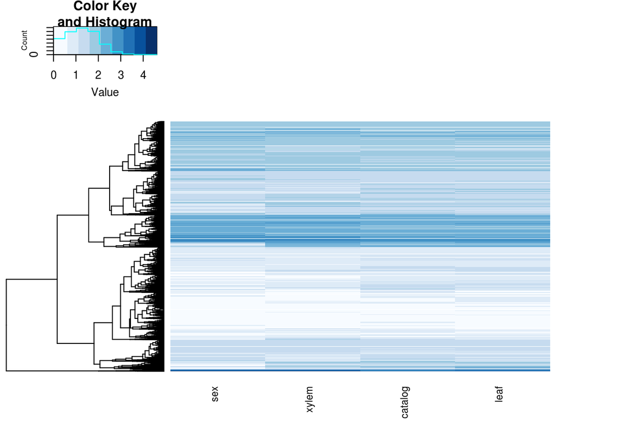

```r
heatmap.2(vst[sel,][rowSums(vst[sel,])>0,],
          labRow = NA,trace = "none",
          dendrogram="row",cexCol=0.8,
          col=brewer.pal(9,"Blues"))
```

# 4 Updates

## 4.1 Events

Summarize the type of events:

- stable: gene structure stable
- split: gene structure split into 2 genes
- merged: several gene structures merged into one
- merged.as.sv: a subset of the above, where different splice variants where also introduced
- novel: novel gene structure
- duplicate: a subset of the above, when the same gene was detected through different supporting evidences
- antisense: a subset of novel, where a gene was reported on the antisense strand

```r
dfs <- mclapply(dir(pattern="\\.csv$"),read.csv,row.names=1,
                stringsAsFactors=FALSE,mc.cores=12)
names(dfs) <- sub("first-iteration","V1",
                  sub("second-iteration","V2",
                      tolower(gsub("Potra01|\\.gene_structures_post_PASA_|-validated-updates\\.csv","",dir(pattern="\\.csv$")))))

events <- sapply(lapply(lapply(dfs,"[[","status"),factor,
                        levels=c("antisense","duplicate","merged","merged.as.sv","novel","split","stable")),table)
```

Get the ID table

```r
ID.df <- read.csv(file="/mnt/picea/storage/reference/Populus-tremula/v1.0/annotation/Potra01-pasa-ID-lift-over.csv",
                  row.names=1,stringsAsFactors=FALSE)
```

Sort the events We drop the first Potri03 iteration (the one done after the xylem)

```r
events <- events[,-match(c("potri03V1","potri03V2"),colnames(events))]
colnames(events) <- sub("potri03post-leaf-","Potri03",colnames(events))
events <- events[,match(colnames(ID.df)[-c(1:2)],colnames(events))]
pander(events)
```

Table continues below

|  | catalogV1 | catalogV2 | sexV1 | sexV2 |
| --- | --- | --- | --- | --- |
| **antisense** | 1 | 0 | 0 | 0 |
| **duplicate** | 13 | 0 | 1 | 0 |
| **merged** | 165 | 48 | 40 | 16 |
| **merged.as.sv** | 2 | 0 | 0 | 0 |
| **novel** | 1259 | 7 | 389 | 1 |
| **split** | 2 | 0 | 0 | 0 |
| **stable** | 27472 | 28763 | 28754 | 29145 |

Table continues below

|  | xylemV1 | xylemV2 | leafV1 | leafV2 |
| --- | --- | --- | --- | --- |
| **antisense** | 0 | 0 | 0 | 0 |
| **duplicate** | 2 | 0 | 2 | 0 |
| **merged** | 37 | 4 | 35 | 4 |
| **merged.as.sv** | 0 | 0 | 0 | 0 |
| **novel** | 239 | 1 | 207 | 3 |
| **split** | 0 | 0 | 4 | 0 |
| **stable** | 29117 | 29369 | 29335 | 29541 |

|  | Potri03V1 | Potri03V2 |
| --- | --- | --- |
| **antisense** | 0 | 0 |
| **duplicate** | 0 | 0 |
| **merged** | 4 | 2 |
| **merged.as.sv** | 0 | 0 |
| **novel** | 539 | 2 |
| **split** | 8 | 0 |
| **stable** | 29538 | 30085 |

### 4.1.1 Quantify the events

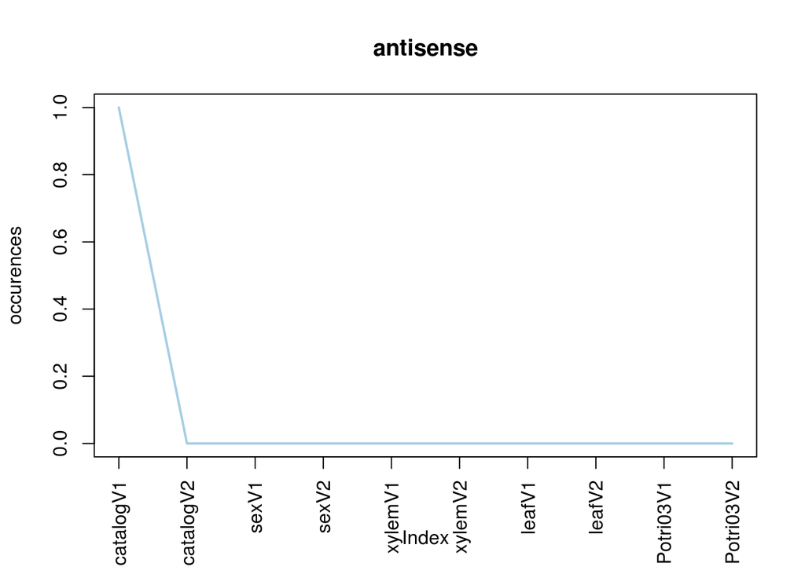

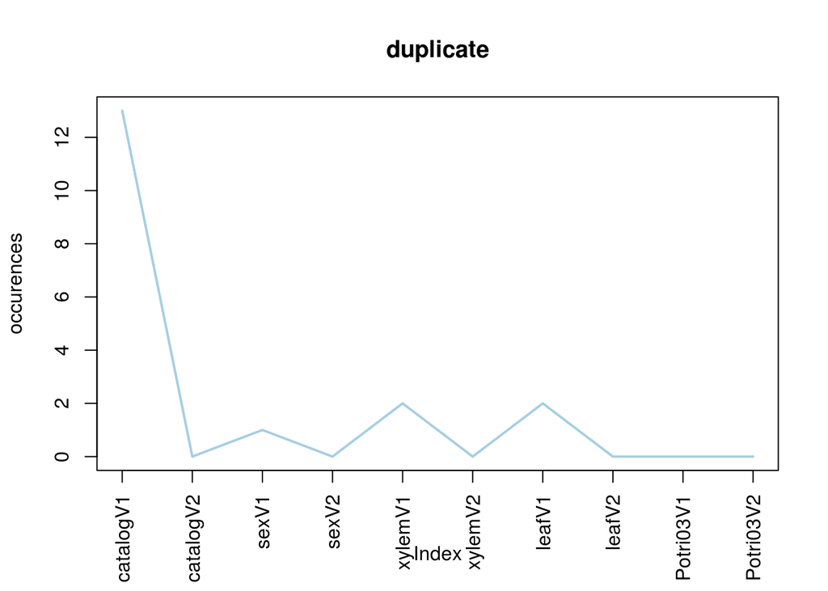

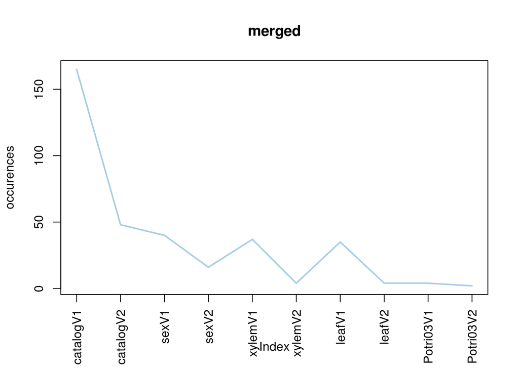

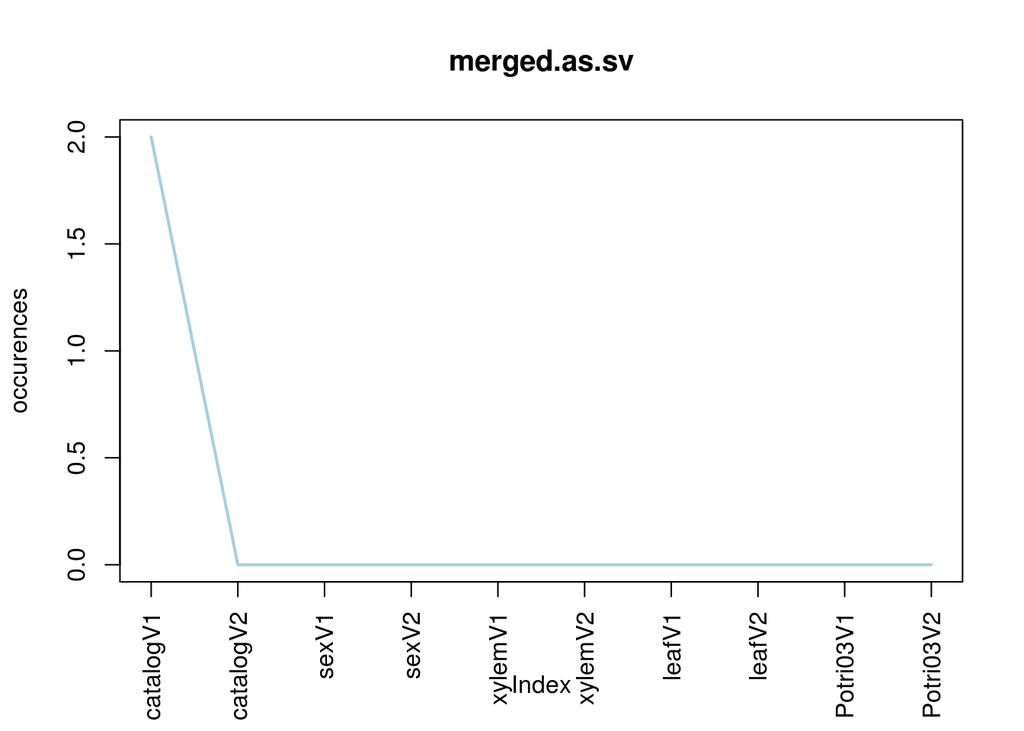

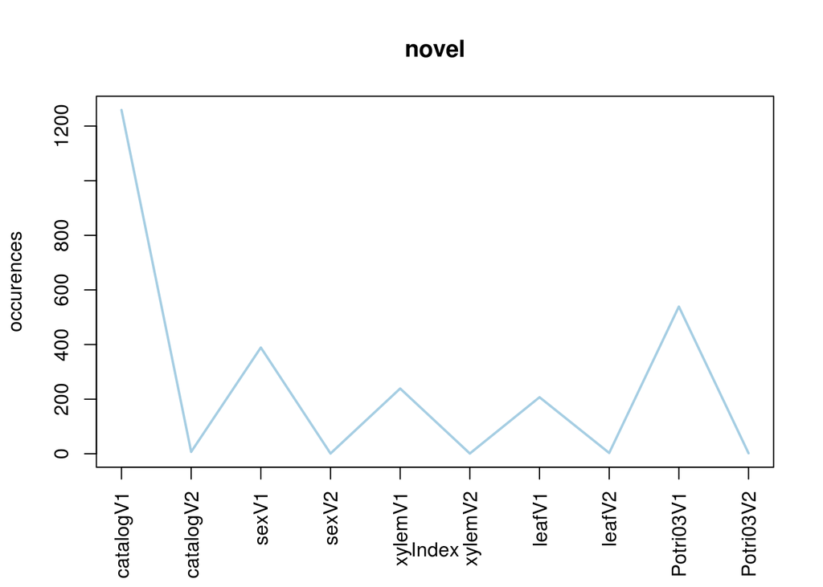

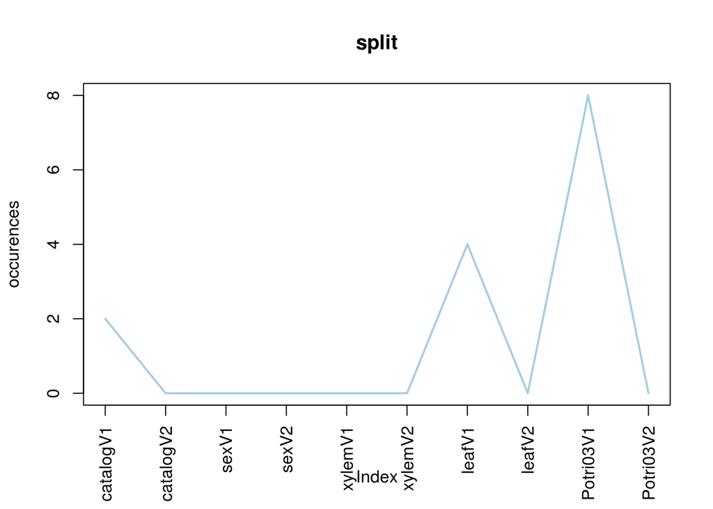

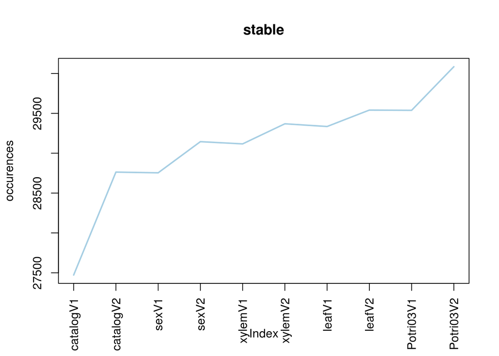

```r
dev.null <- sapply(rownames(events),function(n){
  plot(events[rownames(events)==n,],main=n,col=cols[1],
       lwd=2,type="l",ylab="occurences",xaxt="n")
  axis(1,at = 1:10, labels=colnames(events),las=2)
})
```

### 4.1.2 Quantify other changes

Such as UTR extension or change in exon number First get a list of candidate IDs

```r
names(dfs) <- sub("potri03post-leaf-","Potri03",names(dfs))
dfs <- dfs[match(colnames(ID.df)[-c(1:2)],names(dfs))]
IDs <- Reduce(intersect,
              lapply(dfs[-grep("Potri",
                               names(dfs))],
                     function(df){df[df$status=="stable","newID"]}))
```

Then sub-select the stable one in the leafV2 annotation

```r
sprintf("There are %s genes which are stable between the ab initio and the 'leaf development' dataset",length(IDs))
```

```
## [1] "There are 27352 genes which are stable between the ab initio and the 'leaf development' dataset"
```

#### 4.1.2.1 UTRs

```r
orig.gene <- gffs[["Potra01"]][gffs[["Potra01"]]$type=="gene",]
final.gene <- gffs[["Potra01+PASA"]][gffs[["Potra01+PASA"]]$type=="gene",]
orig.gene <- orig.gene[match(IDs,getGffAttribute(orig.gene,"ID")),]
final.gene <- final.gene[match(IDs,getGffAttribute(final.gene,"ID")),]
```

We have had one ID swap between two genes, so we skip those although they were conserved for the calcuation below

```r
keep <- which(strand(orig.gene) == strand(final.gene))
```

Check whether the UTRs were extended, unchanged or truncated of the genes considered stable (+1, 0 and -1, respectively)

```r
tab <- table(list(
  five_prime=sign(ifelse(orig.gene$strand[keep] == "-",
                         final.gene[keep,2] - orig.gene[keep,2],
                         orig.gene[keep,1] - final.gene[keep,1])),
  tree_prime=sign(ifelse(orig.gene$strand[keep] == "-",
                         orig.gene[keep,1] - final.gene[keep,1],
                         final.gene[keep,2] - orig.gene[keep,2]))))
pander(tab)
```

|  | -1 | 0 | 1 |
| --- | --- | --- | --- |
| **-1** | 85 | 45 | 190 |
| **0** | 69 | 4592 | 2695 |
| **1** | 563 | 3705 | 15406 |

Most of the genes had UTR extension on both ends, or were conserved, A non negigible proportion had only one end extended, which might indicate partial genes.

```r
pander(round(tab/sum(tab),digits=2))
```

|  | -1 | 0 | 1 |
| --- | --- | --- | --- |
| **-1** | 0 | 0 | 0.01 |
| **0** | 0 | 0.17 | 0.1 |
| **1** | 0.02 | 0.14 | 0.56 |

For the fun, just consider this as a contingency table and look at the association plot. Partial genes - i.e. these being stable at one extremity and changing at the other - are overall depleted - all red bins - which is fun to see. Mostly genes had either extremities affected.

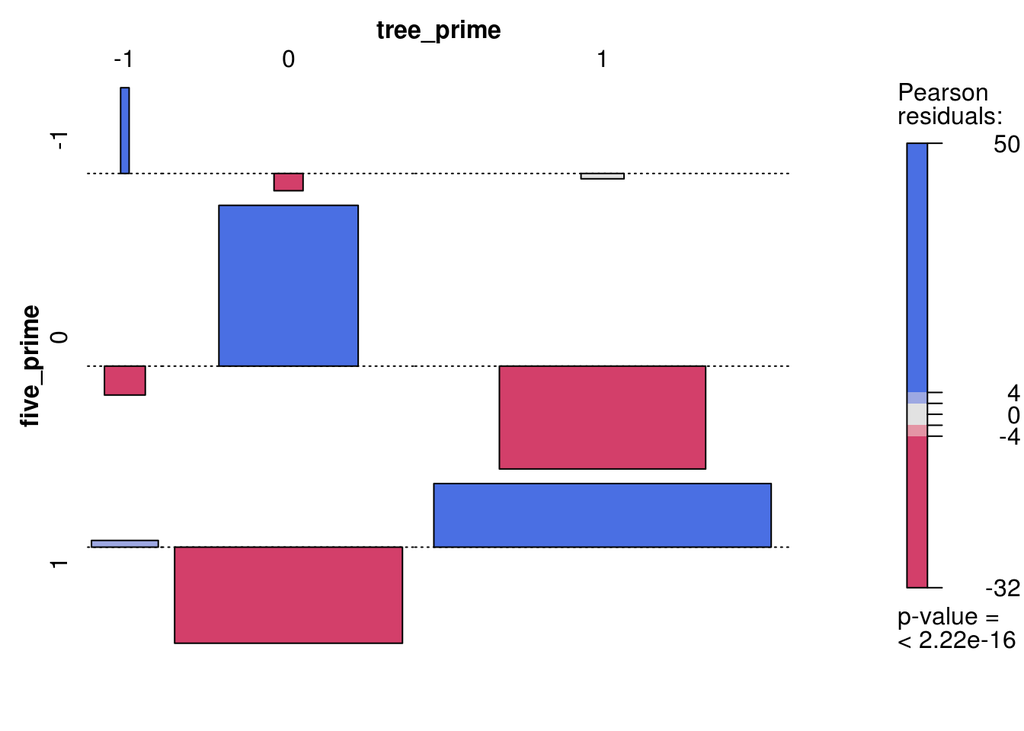

```r
assoc(tab,shade=TRUE)
```

Look at the size variation

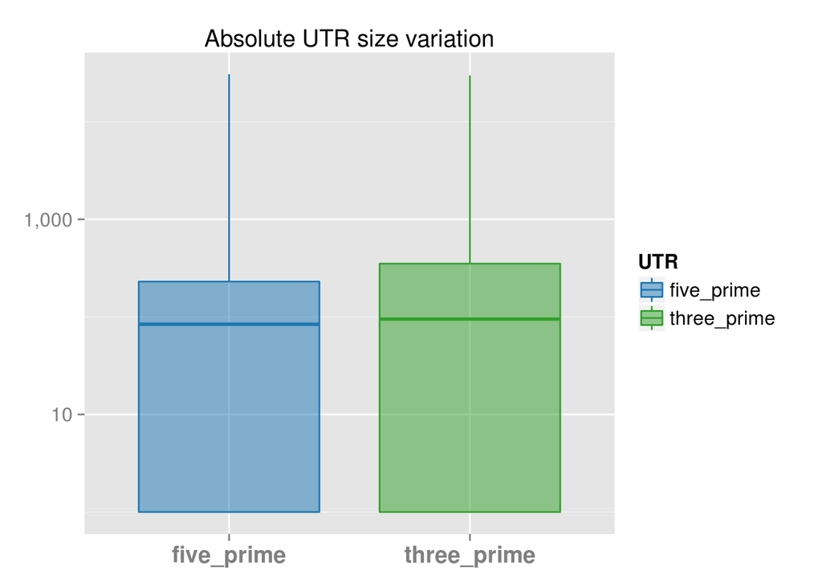

```r
df.UTR <- data.frame(UTR=rep(c("five_prime","three_prime"),
                             each=nrow(orig.gene[keep,])),
                     Length=c(
                       abs(ifelse(orig.gene$strand[keep] == "-",
                                  final.gene[keep,2] - orig.gene[keep,2],
                                  orig.gene[keep,1] - final.gene[keep,1]))+1,

                       abs(ifelse(orig.gene$strand[keep] == "-",
                                  orig.gene[keep,1] - final.gene[keep,1],
                                  final.gene[keep,2] - orig.gene[keep,2]))+1))

ggplot(df.UTR, aes(x=UTR,y=Length,fill=UTR,color=UTR,alpha=UTR)) +
  geom_boxplot() +
  scale_y_log10(labels=comma) +
  scale_fill_manual(values=cols[c(2,4)]) +
  scale_color_manual(values=cols[c(2,4)]) +
  scale_alpha_manual(values=c(.5,.5)) +
  theme(axis.text.x=element_text(size=14,face="bold"),
        axis.text.y=element_text(size=12),
        axis.title=element_blank(),
        legend.text=element_text(size=12),
        legend.title=element_text(size=12)) +
  ggtitle("Absolute UTR size variation")
```

#### 4.1.2.2 Number of mRNA

Most had one or more mRNA added.

```r
orig.mRNA <- gffs[["Potra01"]][gffs[["Potra01"]]$type=="mRNA",]
final.mRNA <- gffs[["Potra01+PASA"]][gffs[["Potra01+PASA"]]$type=="mRNA",]
orig.mRNA <- orig.mRNA[getGffAttribute(orig.mRNA,"Parent") %in% IDs,]
final.mRNA <- final.mRNA[getGffAttribute(final.mRNA,"Parent") %in% IDs,]
orig.tab <- table(getGffAttribute(orig.mRNA,"Parent"))
final.tab <- table(getGffAttribute(final.mRNA,"Parent"))
stopifnot(all(names(orig.tab) == names(final.tab)))
tab <- table(as.integer(final.tab) - as.integer(orig.tab))
pander(tab)
```

Table continues below

| 0 | 1 | 2 | 3 | 4 | 5 | 6 | 7 | 8 | 9 |
| --- | --- | --- | --- | --- | --- | --- | --- | --- | --- |
| 11663 | 5559 | 3577 | 2365 | 1538 | 972 | 638 | 369 | 253 | 163 |

Table continues below

| 10 | 11 | 12 | 13 | 14 | 15 | 16 | 17 | 18 | 21 |
| --- | --- | --- | --- | --- | --- | --- | --- | --- | --- |
| 105 | 48 | 37 | 24 | 22 | 5 | 5 | 5 | 1 | 2 |

| 22 |
| --- |
| 1 |

```r
pander(tab/sum(tab))
```

Table continues below

| 0 | 1 | 2 | 3 | 4 | 5 | 6 |
| --- | --- | --- | --- | --- | --- | --- |
| 0.4264 | 0.2032 | 0.1308 | 0.08647 | 0.05623 | 0.03554 | 0.02333 |

Table continues below

| 7 | 8 | 9 | 10 | 11 | 12 |
| --- | --- | --- | --- | --- | --- |
| 0.01349 | 0.00925 | 0.005959 | 0.003839 | 0.001755 | 0.001353 |

Table continues below

| 13 | 14 | 15 | 16 | 17 | 18 |
| --- | --- | --- | --- | --- | --- |
| 0.0008774 | 0.0008043 | 0.0001828 | 0.0001828 | 0.0001828 | 3.656e-05 |

| 21 | 22 |
| --- | --- |
| 7.312e-05 | 3.656e-05 |

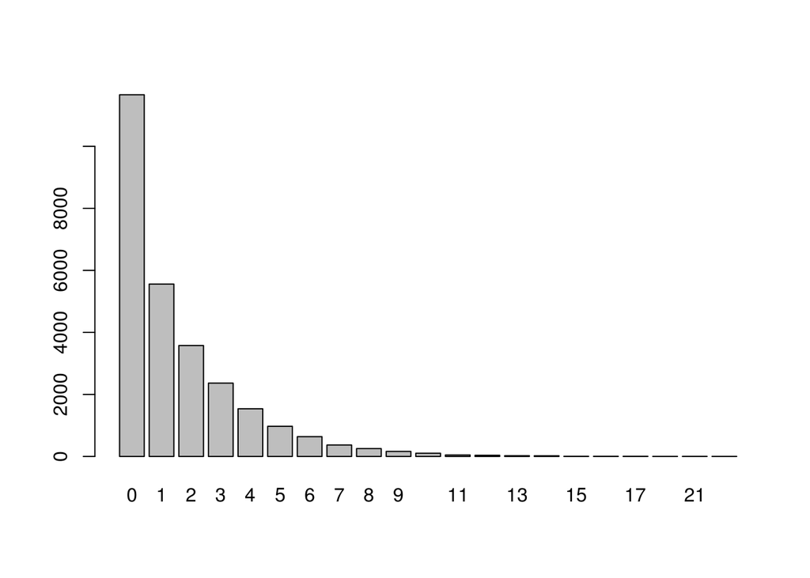

```r
barplot(tab)
```

#### 4.1.2.3 Number of exons

```r
orig.exon <- gffs[["Potra01"]][gffs[["Potra01"]]$type=="exon",]
final.exon <- gffs[["Potra01+PASA"]][gffs[["Potra01+PASA"]]$type=="exon",]
```

Subset to the mRNA above

The ab initio has comma separated IDs, keep only one

```r
orig.exon <- orig.exon[sub(",.*","",getGffAttribute(orig.exon,"Parent")) %in%
                         getGffAttribute(orig.mRNA,"ID"),]

final.exon <- final.exon[getGffAttribute(final.exon,"Parent") %in%
                           getGffAttribute(final.mRNA,"ID"),]
```

Remove the duplicates We do not expect any in out ab initio prediction (ID are duplicated)

```r
orig.dup <- duplicated(paste(seq_name(orig.exon),orig.exon[,1],
                             orig.exon[,2],orig.exon$strand,sep="_"))
stopifnot(sum(orig.dup)==0)

final.dup <- duplicated(paste(seq_name(final.exon),final.exon[,1],
                              final.exon[,2],final.exon$strand,sep="_"))
```

and tabulate the number of exon per mRNA

```r
orig.exon.tab <- table(sub("\\..*","",getGffAttribute(orig.exon,"Parent")))
final.exon.tab <- table(sub("\\..*","",getGffAttribute(final.exon[!final.dup,],"Parent")))
stopifnot(length(orig.exon.tab) == length(final.exon.tab))
stopifnot(all(names(orig.exon.tab) == names(final.exon.tab)))
exon.tab <- table(as.integer(final.exon.tab) - as.integer(orig.exon.tab))
pander(exon.tab)
```

Table continues below

| -13 | -12 | -11 | -10 | -9 | -8 | -7 | -6 | -5 |
| --- | --- | --- | --- | --- | --- | --- | --- | --- |
| 2 | 1 | 1 | 3 | 2 | 3 | 4 | 6 | 21 |

Table continues below

| -4 | -3 | -2 | -1 | 0 | 1 | 2 | 3 | 4 | 5 |
| --- | --- | --- | --- | --- | --- | --- | --- | --- | --- |
| 27 | 59 | 170 | 740 | 9707 | 2876 | 2962 | 2311 | 1808 | 1568 |

Table continues below

| 6 | 7 | 8 | 9 | 10 | 11 | 12 | 13 | 14 | 15 |
| --- | --- | --- | --- | --- | --- | --- | --- | --- | --- |
| 1233 | 922 | 684 | 564 | 427 | 320 | 251 | 175 | 130 | 85 |

Table continues below

| 16 | 17 | 18 | 19 | 20 | 21 | 22 | 23 | 24 | 25 |
| --- | --- | --- | --- | --- | --- | --- | --- | --- | --- |
| 84 | 53 | 39 | 31 | 27 | 25 | 7 | 5 | 6 | 6 |

| 26 | 27 | 28 | 31 | 37 | 38 |
| --- | --- | --- | --- | --- | --- |
| 2 | 1 | 1 | 1 | 1 | 1 |

```r
pander(exon.tab/sum(exon.tab))
```

Table continues below

| -13 | -12 | -11 | -10 | -9 | -8 |
| --- | --- | --- | --- | --- | --- |
| 7.312e-05 | 3.656e-05 | 3.656e-05 | 0.0001097 | 7.312e-05 | 0.0001097 |

Table continues below

| -7 | -6 | -5 | -4 | -3 | -2 |
| --- | --- | --- | --- | --- | --- |
| 0.0001462 | 0.0002194 | 0.0007678 | 0.0009871 | 0.002157 | 0.006215 |

Table continues below

| -1 | 0 | 1 | 2 | 3 | 4 | 5 |
| --- | --- | --- | --- | --- | --- | --- |
| 0.02705 | 0.3549 | 0.1051 | 0.1083 | 0.08449 | 0.0661 | 0.05733 |

Table continues below

| 6 | 7 | 8 | 9 | 10 | 11 | 12 |
| --- | --- | --- | --- | --- | --- | --- |
| 0.04508 | 0.03371 | 0.02501 | 0.02062 | 0.01561 | 0.0117 | 0.009177 |

Table continues below

| 13 | 14 | 15 | 16 | 17 | 18 |
| --- | --- | --- | --- | --- | --- |
| 0.006398 | 0.004753 | 0.003108 | 0.003071 | 0.001938 | 0.001426 |

Table continues below

| 19 | 20 | 21 | 22 | 23 | 24 |
| --- | --- | --- | --- | --- | --- |
| 0.001133 | 0.0009871 | 0.000914 | 0.0002559 | 0.0001828 | 0.0002194 |

Table continues below

| 25 | 26 | 27 | 28 | 31 | 37 |
| --- | --- | --- | --- | --- | --- |
| 0.0002194 | 7.312e-05 | 3.656e-05 | 3.656e-05 | 3.656e-05 | 3.656e-05 |

| 38 |
| --- |
| 3.656e-05 |

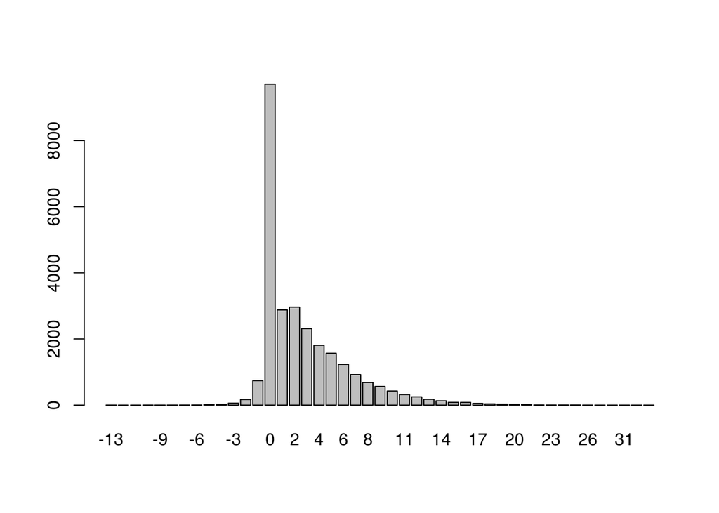

```r
barplot(exon.tab)
```

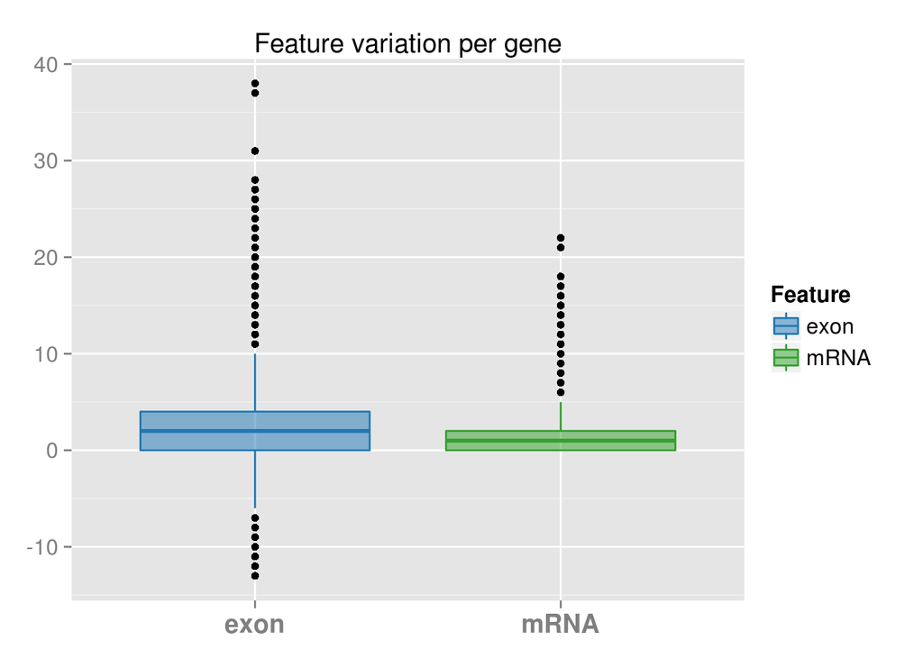

```r
# And plot both data (mRNA and exons)
df.variation <- data.frame(Feature=rep(c("exon","mRNA"),
                                       each=length(orig.exon.tab)),
                           Variation=c(as.integer(final.exon.tab) - as.integer(orig.exon.tab),
                                       as.integer(final.tab) - as.integer(orig.tab))
)

ggplot(df.variation, aes(x=Feature,y=Variation,fill=Feature,
                         color=Feature,alpha=Feature)) +
  geom_boxplot() +
  scale_y_continuous(labels=comma) +
  scale_fill_manual(values=cols[c(2,4)]) +
  scale_color_manual(values=cols[c(2,4)]) +
  scale_alpha_manual(values=c(.5,.5)) +
  theme(axis.text.x=element_text(size=14,face="bold"),
        axis.text.y=element_text(size=12),
        axis.title=element_blank(),
        legend.text=element_text(size=12),
        legend.title=element_text(size=12)) +
  ggtitle("Feature variation per gene")
```